# 2017_02_Homework_python

**Introduction to Machine Learning**  
**Homework 2**  
**Due Thursday, 10/12/2017, 10:30 AM**

|  | by Seungchul Lee iSystems Design Lab UNIST http://isystems.unist.ac.kr/ |
| --- | --- |

- Please send your .ipynb file to e-mail (hojin12312@gmail.com) for your code score.
- Your printed code will not be scored.

## Problem 1

The regularized least-squares problem has the form

$$ \min_{\theta} \;\lVert A\theta -y\rVert_2^2 + \lambda \lVert \theta \rVert_2^2$$

1. Show that the solution is given by
   $$ \hat{\theta} = \left( A^T A + \lambda I_n \right)^{-1} A^T y $$ (Do not use the method of Lagrangian multipliers)
2. Find and plot an approximated curve of the given data points in either Matlab or python
   - overcome overfitting
   - use RBF
   - choose a proper value of $\lambda$ on your own

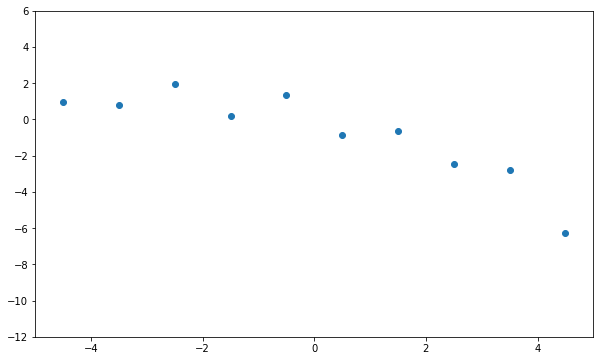

```python
import numpy as np
import matplotlib.pyplot as plt

x = np.linspace(-4.5, 4.5, 10)
y = np.array([0.9819, 0.7973, 1.9737, 0.1838, 1.3180, -0.8361, -0.6591, -2.4701, -2.8122, -6.2512])

plt.figure(figsize = (10,6))
plt.plot(x, y, 'o')
plt.axis([-5, 5, -12, 6])
plt.show()
```

## Problem 2

Let $f(x_1,x_2) = 2x_1 + 3x_2 + 1 = 0$ be the hyperplane (or decision surface in classification problems). Compute the shortest distances from $x_a = \begin{bmatrix} 2 \\1\end{bmatrix}$ and $x_b = \begin{bmatrix} 1 \\ -1\end{bmatrix}$ to the above hyperplane.

## Problem 3

Find the solution $r$ of the below optimization problem with the following objective function and constraint. ($x, \omega, \omega_0 \in \mathbb{R}^n$)

$$ \begin{align*} r = \;&\min_x \;\rVert x \lVert_2\\ \text{s.t.}&\; \omega^T x + \omega_0 = 0 \end{align*}$$

## Problem 4

In this problem, we will try to classify handwritten digits. For the sake of simplicity, we simplify this digit classification problem into a binary classification between digit 0 and digit 1.

### Step 1. Load the data

| Data | Data dexcription |
| --- | --- |
| 0 | 1000 images (28×28 pixels) of handwritten digit 0 |
| 1 | 1000 images (28×28 pixels) of handwritten digit 1 |

[download data](https://www.dropbox.com/s/y8pkwhkh1hcn9g6/data.pkl?dl=1) to read the files in Python.

To read the files in Python, use the following code:

```
import matplotlib.pyplot as plt
from six.moves import cPickle
data = cPickle.load(open('./data.pkl', 'rb'))
data0 = data['0']
data1 = data['1']

img = data0[k]
```

Here, we will load 1000 numbers of data from ‘0’ and ‘1’. To display the image use `plt.imshow(img)`.

Note: make sure you are reading the files correctly. Check by displaying the first few and the last few images in each class.

Note: calculations are more manageable if you go though and convert each of the pixels in $28\times28$ matrix to a binary value first.

```
# Convert to binary image
data0 = data0 > 125
```

### Step 2. Extract features

Now we must select the own ‘features’ from image data to detect digit 0 and digit 1. Two features are recommended

1) The total average pixels located at the center of the image (`img[10:20,10:20]`).

2) The total average pixels over the entire location.

3) Include the ones as our bias term.

$$\Phi(x) = \begin{bmatrix} 1 \\ \text{feature1}\\ \text{feature2} \end{bmatrix}$$

You should end up with a $2000\times3$ input matrix with the first $1000$ rows correspond to all of the ‘`data0`’ and the second 1000 rows correspond to the two features for all of the given ‘`data1`’. This matrix is matrix $\Phi$ which we learned in a class.

### Step 3. Plot the data

Plot the data to see if classes are separable. The expected plot is the following:

[figure not shown]

## Problem 5

We would like to use the perceptron algorithm to classify digit 0 and digit 1 in the training set.

### Step 1. Initialization

You have to initialize $\omega$ . We usually set $\omega$ to a zero vector as an initial guess.

### Step 2. Update $\omega$

We update $\omega$ when the prediction is wrong. The update rule is the following:

$$ \omega \leftarrow \omega + y \cdot x$$

```
For k = 1:100 {
      For j = 1:100 {
            i = random integer selection between 1 and 2000
            compute yhat(i)
            if yhat(i) is wrong {
                w = w + y(i)x(i)
            }
    }
}
```

For every $k$'s iteration, count and store how many predictions are wrong to see if your classifier converges to somewhere or not.

### Step 3. Plot the result

You are asked to plot two graphs. First, plot the number of wrong predictions with respect to every $k$'s iteration. The graph is expected as follows:

[figure not shown]

Second, plot the classifier (decision boundary). Note that the decision boundary is given:

$$\omega_1 x_1 + \omega_2x_2 + \omega_0 = 0$$

The expected graph is the following

[figure not shown]